# chipMap

Xons

2016-10-20

# Install

```r
install_github('devtools')
library('devtools')
install_github('chipMap','xons')
library('chipMap')
```

# Get start

> We need a bed file of peak regions, can be a result from a ChIPseq peak calling. For example, a bed file ‘peak_example.bed’.

```r
peak=bed2gr('peak_example.bed')
head(peak)
```

```
## GRanges object with 6 ranges and 1 metadata column:
##       seqnames             ranges strand |  peak_index
##          <Rle>          <IRanges>  <Rle> | <character>
##   [1]     chr1 [3062754, 3063064]      * |           1
##   [2]     chr1 [3670687, 3671024]      * |           2
##   [3]     chr1 [4150826, 4151217]      * |           3
##   [4]     chr1 [4284846, 4285616]      * |           4
##   [5]     chr1 [4802575, 4802913]      * |           5
##   [6]     chr1 [4855224, 4855786]      * |           6
##   -------
##   seqinfo: 27 sequences from an unspecified genome; no seqlengths
```

> And a transcript/gene annotation file. For example, ‘transcripts_example.txt’.

```r
tx=read.delim('transcripts_example.txt')
head(tx)
```

```
##                 txid seqnames   start     end strand   gene_symbol
## 1 ENSMUST00000193812     chr1 3073253 3074322      1 4933401J01Rik
## 2 ENSMUST00000082908     chr1 3102016 3102125      1       Gm26206
## 3 ENSMUST00000162897     chr1 3205901 3216344     -1          Xkr4
## 4 ENSMUST00000159265     chr1 3206523 3215632     -1          Xkr4
## 5 ENSMUST00000070533     chr1 3214482 3671498     -1          Xkr4
## 6 ENSMUST00000192857     chr1 3252757 3253236      1       Gm18956
##      ensembl_gene_id gene_start gene_end
## 1 ENSMUSG00000102693    3073253  3074322
## 2 ENSMUSG00000064842    3102016  3102125
## 3 ENSMUSG00000051951    3205901  3671498
## 4 ENSMUSG00000051951    3205901  3671498
## 5 ENSMUSG00000051951    3205901  3671498
## 6 ENSMUSG00000102851    3252757  3253236
```

## Annotate the peak

> The heatmap can be made without this step. Here we will do further annotation before making heatmaps.

```r
ann=annPeak(peak,tx) ##　annotate the peaks with nearest transcripts/genes
ann_tss=annPeak_bytss(peak,tx)　## annotate the peaks with nearest TSS

head(ann)
```

```
##    seqnames peak_start peak_end peak_width peak_strand peak_index seqnames
## 1      chr1    3062754  3063064        311           *          1     chr1
## 5      chr1    3670687  3671024        338           *          2     chr1
## 20     chr1    4150826  4151217        392           *          3     chr1
## 21     chr1    4284846  4285616        771           *          4     chr1
## 52     chr1    4802575  4802913        339           *          5     chr1
## 55     chr1    4855224  4855786        563           *          6     chr1
##      start     end  width strand               txid distance
## 1  3073253 3074322   1070      + ENSMUST00000193812    10188
## 5  3214482 3671498 457017      - ENSMUST00000070533        0
## 20 4256234 4260519   4286      - ENSMUST00000195384   105016
## 21 4290846 4409241 118396      - ENSMUST00000194992     5229
## 52 4807788 4848410  40623      + ENSMUST00000134384     4874
## 55 4807892 4886770  78879      + ENSMUST00000155020        0
##    peak_to_feature
## 1         upstream
## 5      overlap_tss
## 20      downstream
## 21      downstream
## 52        upstream
## 55            body
```

```r
head(ann_tss)
```

```
##      seqnames peak_start peak_end peak_width peak_strand peak_index
## 1        chr1    3062754  3063064        311           *          1
## 5        chr1    3670687  3671024        338           *          2
## 20       chr1    4150826  4151217        392           *          3
## 20.1     chr1    4284846  4285616        771           *          4
## 52       chr1    4802575  4802913        339           *          5
## 61       chr1    4855224  4855786        563           *          6
##      seqnames   start     end  width strand               txid distance
## 1        chr1 3073253 3074322   1070      + ENSMUST00000193812     9188
## 5        chr1 3214482 3671498 457017      - ENSMUST00000070533        0
## 20       chr1 4256234 4260519   4286      - ENSMUST00000195384   108301
## 20.1     chr1 4256234 4260519   4286      - ENSMUST00000195384    23326
## 52       chr1 4807788 4848410  40623      + ENSMUST00000134384     3874
## 61       chr1 4857814 4897905  40092      + ENSMUST00000081551     1027
##          tss  center distance_center_to_tss
## 1    3073253 3062909                 -10344
## 5    3671498 3670856                      0
## 20   4260519 4151022                 109497
## 20.1 4260519 4285231                 -24712
## 52   4807788 4802744                  -5044
## 61   4857814 4855505                  -2309
```

```r
plotPie(ann,'peak_example') ## image is autosaved as PNG. PDF can be saved if out.pdf=TRUE.
```

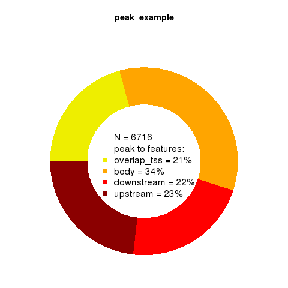

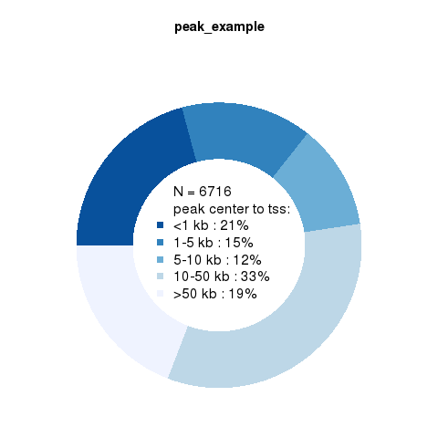

```r
plotPie_tss(ann_tss,'peak_example') ## image is autosaved as PNG. PDF can be saved if out.pdf=TRUE.
```

## Heatmap

> We need BigWig files for making the heatmap. Here is an example using ‘peak_example.bw’ and ‘H3K4me3_example.bw’.

```r
fls=c('peak_example.bw','H3K4me3_example.bw')
bwls=lapply(fls,bw2coverage)
names(bwls)=fls
```

> **Centered at TSS**

> Use tssMap function to make heatmaps centered at TSS. It can be done with any given TSS with the columns requested by tssMap function. Here we centered at the nearest gene of peaks as an example and make a heatmap of H3K4me3.

```r
## Filter to keep unique TSS that overlapping with peaks and sort the TSS by the occupancy of H3K4me3.
ann_tss_sub=subset(ann_tss,distance==0) ## get TSS with peak
ann_tss_uq=ann_tss_sub[!duplicated(ann_tss_sub$txid),] ## get unique TSS
## Calculate the matrix
query=bwls[[2]]
mx=tssMap(query,anndf=ann_tss_uq) #Default is -5 kb to 5 kb around TSS.
ord=order(rowSums(mx),decreasing=T)
mx.sort=mx[ord,] #sort the TSS by the occupancy of H3K4me3
## Plot the heatmap
plotMX(list(peak_example=mx.sort),output="heatmap_peak.pdf")
```

> A PDF version of the heatmap and colorbar are saved to allow text editing, like this:

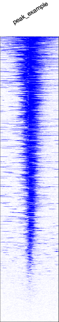

> We can make heatmap of multiple samples. Here we just show two samples, it can be much more.

```r
ann_tss_uq_sort=ann_tss_uq[ord,] #sort the TSS by the occupancy of H3K4me3
mxls=lapply(bwls,tssMap,anndf=ann_tss_uq_sort) # This step can be paralleled using mclapply.
plotMX(mxls,output="heatmap.tss.center.pdf")
```

> A PDF version of the heatmap and colorbar are saved to allow text editing, like this:

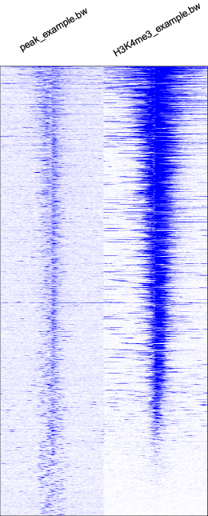

> We can make the meta plot, the mean of each column, to give a summary profile of the matrix.

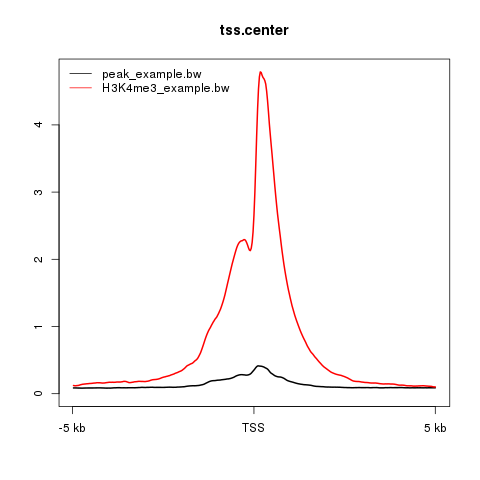

```r
metaPlot(mxls, titles="tss.center", center="tss") ## image is autosaved as PNG. PDF can be saved if out.pdf=TRUE.
```

> **Centered at peak center**

> Use peakMap to center the heatmap at the middle of the peak. Here we use annotated peak data frame as an example. It can be any given peak regions with the columns requested by peakMap function.

```r
## Calculate the matrix, sort the peak by the peak width.
mxls.peak=lapply(bwls,peakMap,anndf=ann_tss,sortByWidth=TRUE) #Default is -5 kb to 5 kb around peak center.
## Plot the heatmap
plotMX(mxls.peak,output="heatmap.peak.center.pdf")
```

```r
## metaPlot
metaPlot(mxls.peak, titles="peak.center", center="peak")
```

> A PDF version of the heatmap and colorbar are saved to allow text editing, like this:

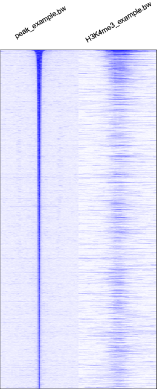

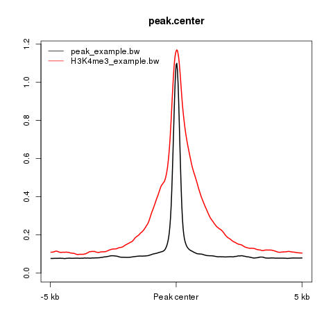

> We can sort the peak by the distance of peak center to its nearest TSS.

```r
## sort the peak by distance_center_to_tss.
ann_tss_sort_dis=ann_tss[order(ann_tss$distance_center_to_tss),]
## Calculate the matrix of -5 kb to 5 kb around peak center.
mxls.peak.dis=lapply(bwls,peakMap,anndf=ann_tss_sort_dis, left= -5000, right=5000, bin_width=25)
## Plot the heatmap
plotMX(mxls.peak.dis,output="heatmap.peak.center.dis.pdf")
```

> A PDF version of the heatmap and colorbar are saved to allow text editing, like this:

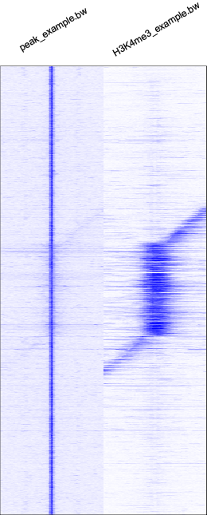

> Tip: The peaks can be separated into groups by overlapping TSS or not and make heatmap separately. Just split the annotated peak data frame ‘ann’ or ‘ann_tss’ into groups based on ‘peak_to_feature’ or ‘distance’ column.

## Enrichment profile

> Instead of heatmap, we can plot enrichment profile, which is binary profile of peak binding. It shows whether there is a peak or not at certain location. It contrasts from the background input by peak calling, so it is much cleaner than the heatmap.

> Instead of BigWig files, we just need Bed files to make the enrichment profile.

> **Centered at TSS**

```r
h3k4me3=bed2gr('H3K4me3_peak.bed')
pls=list(peak_example=peak,H3K4me3=h3k4me3) ## a list of GRanges

mxls.enrich=lapply(pls,tssMap,anndf=ann_tss_uq_sort)
plotMX(mxls.enrich,output="enrich.tss.center.pdf",color=c("white","purple"))
```

```r
metaPlot(mxls.enrich, titles="enrich.tss.center", center="tss")
```

> PDF output enrichment profile is saved (the colorbar is useless here), like this:

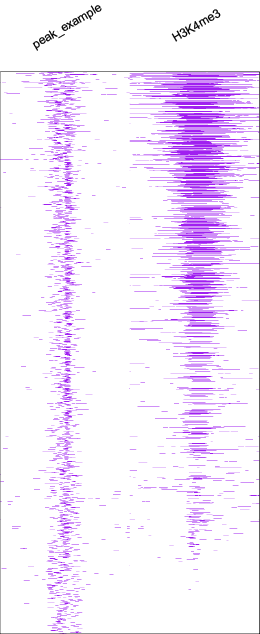

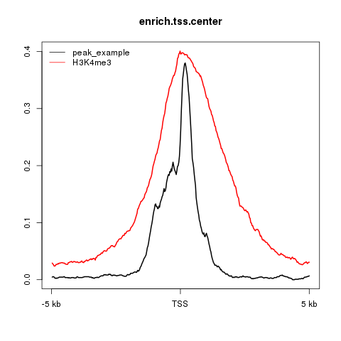

> **Centered at peak center**

```r
## Calculate the matrix
mxls.peak.enrich=lapply(pls,peakMap,anndf=ann_tss,sortByWidth=TRUE) #Default is -5 kb to 5 kb around peak center.
## Plot the enrichment profile
plotMX(mxls.peak.enrich,output="enrich.peak.center.pdf",color=c("white","purple"))
```

```r
## metaPlot
metaPlot(mxls.peak.enrich, "enrich.peak.center", center="peak")
```

> PDF output enrichment profile is saved, like this:

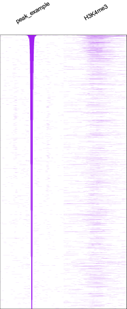

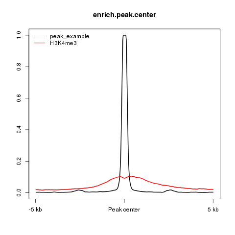

> We can sort the peak by the distance of peak center to its nearest TSS.

```r
## Calculate the matrix of -5 kb to 5 kb around peak center.
mxls.peak.dis.enrich=lapply(pls,peakMap,anndf=ann_tss_sort_dis)
## Plot the enrichment profile
plotMX(mxls.peak.dis.enrich,output="enrich.peak.center.dis.pdf",color=c("white","purple"))
```

> PDF output enrichment profile is saved, like this:

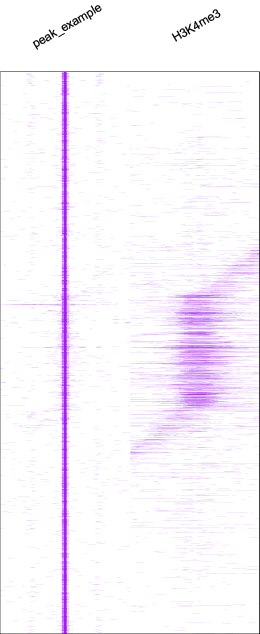